# "What makes us happy?"

A question we've explored extensively, but fail to answer regularly. So they made a questionaire to explore these in "The World Happiness Report". Six measurements are taken per country:

GDP per Capita, Family, Life Expectancy, Freedom, Generosity, Trust Government Corruption

```python
# Dependencies
import pandas as pd
import seaborn as sns
import numpy as np
from matplotlib import pyplot as plt
import plotly.express as px
import requests

# for interactive visualizations
import plotly.offline as py
from plotly.offline import init_notebook_mode, iplot
import plotly.graph_objs as go
init_notebook_mode(connected = True)
```

```python
# File Path, read CSV

#df_2017 = pd.read_csv("2017.csv")
#df_2018 = pd.read_csv("2018.csv")
df_2019 = pd.read_csv("2019.csv")
df_2019.head()
```

|  | Overall rank | Country or region | Score | GDP per capita | Social support | Healthy life expectancy | Freedom to make life choices | Generosity | Perceptions of corruption |
| --- | --- | --- | --- | --- | --- | --- | --- | --- | --- |
| 0 | 1 | Finland | 7.769 | 1.340 | 1.587 | 0.986 | 0.596 | 0.153 | 0.393 |
| 1 | 2 | Denmark | 7.600 | 1.383 | 1.573 | 0.996 | 0.592 | 0.252 | 0.410 |
| 2 | 3 | Norway | 7.554 | 1.488 | 1.582 | 1.028 | 0.603 | 0.271 | 0.341 |
| 3 | 4 | Iceland | 7.494 | 1.380 | 1.624 | 1.026 | 0.591 | 0.354 | 0.118 |
| 4 | 5 | Netherlands | 7.488 | 1.396 | 1.522 | 0.999 | 0.557 | 0.322 | 0.298 |

```python
df_2019.rename({'Overall rank':'Rank', 'Country or region':'Country', 'Score':'Score','GDP per capita':'GDP','Social support':'Family', 'Healthy life expectancy':'Life', 'Freedom to make life choices':'Freedom', 'Perceptions of corruption': 'Trust'}, axis=1, inplace=True)
# Show Data
df_2019.head()
```

|  | Rank | Country | Score | GDP | Family | Life | Freedom | Generosity | Trust |
| --- | --- | --- | --- | --- | --- | --- | --- | --- | --- |
| 0 | 1 | Finland | 7.769 | 1.340 | 1.587 | 0.986 | 0.596 | 0.153 | 0.393 |
| 1 | 2 | Denmark | 7.600 | 1.383 | 1.573 | 0.996 | 0.592 | 0.252 | 0.410 |
| 2 | 3 | Norway | 7.554 | 1.488 | 1.582 | 1.028 | 0.603 | 0.271 | 0.341 |
| 3 | 4 | Iceland | 7.494 | 1.380 | 1.624 | 1.026 | 0.591 | 0.354 | 0.118 |
| 4 | 5 | Netherlands | 7.488 | 1.396 | 1.522 | 0.999 | 0.557 | 0.322 | 0.298 |

```python
#Check for null values in the dataframe
df_2019.isnull().sum()
```

```
Rank          0
Country       0
Score         0
GDP           0
Family        0
Life          0
Freedom       0
Generosity    0
Trust         0
dtype: int64
```

## Analyze the data

```python
df_2019.describe()
```

|  | Rank | Score | GDP | Family | Life | Freedom | Generosity | Trust |
| --- | --- | --- | --- | --- | --- | --- | --- | --- |
| count | 156.000000 | 156.000000 | 156.000000 | 156.000000 | 156.000000 | 156.000000 | 156.000000 | 156.000000 |
| mean | 78.500000 | 5.407096 | 0.905147 | 1.208814 | 0.725244 | 0.392571 | 0.184846 | 0.110603 |
| std | 45.177428 | 1.113120 | 0.398389 | 0.299191 | 0.242124 | 0.143289 | 0.095254 | 0.094538 |
| min | 1.000000 | 2.853000 | 0.000000 | 0.000000 | 0.000000 | 0.000000 | 0.000000 | 0.000000 |
| 25% | 39.750000 | 4.544500 | 0.602750 | 1.055750 | 0.547750 | 0.308000 | 0.108750 | 0.047000 |
| 50% | 78.500000 | 5.379500 | 0.960000 | 1.271500 | 0.789000 | 0.417000 | 0.177500 | 0.085500 |
| 75% | 117.250000 | 6.184500 | 1.232500 | 1.452500 | 0.881750 | 0.507250 | 0.248250 | 0.141250 |
| max | 156.000000 | 7.769000 | 1.684000 | 1.624000 | 1.141000 | 0.631000 | 0.566000 | 0.453000 |

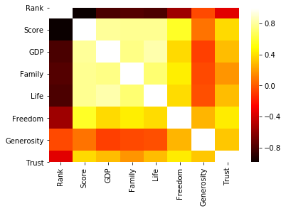

```python
#Correlation Part.
corr = df_2019.corr()
sns.heatmap(corr, xticklabels=corr.columns, yticklabels=corr.columns , cmap='hot')
```

```python
corr[abs(corr['Score']) > 0.1]['Score']
```

```
Rank      -0.989096
Score      1.000000
GDP        0.793883
Family     0.777058
Life       0.779883
Freedom    0.566742
Trust      0.385613
Name: Score, dtype: float64
```

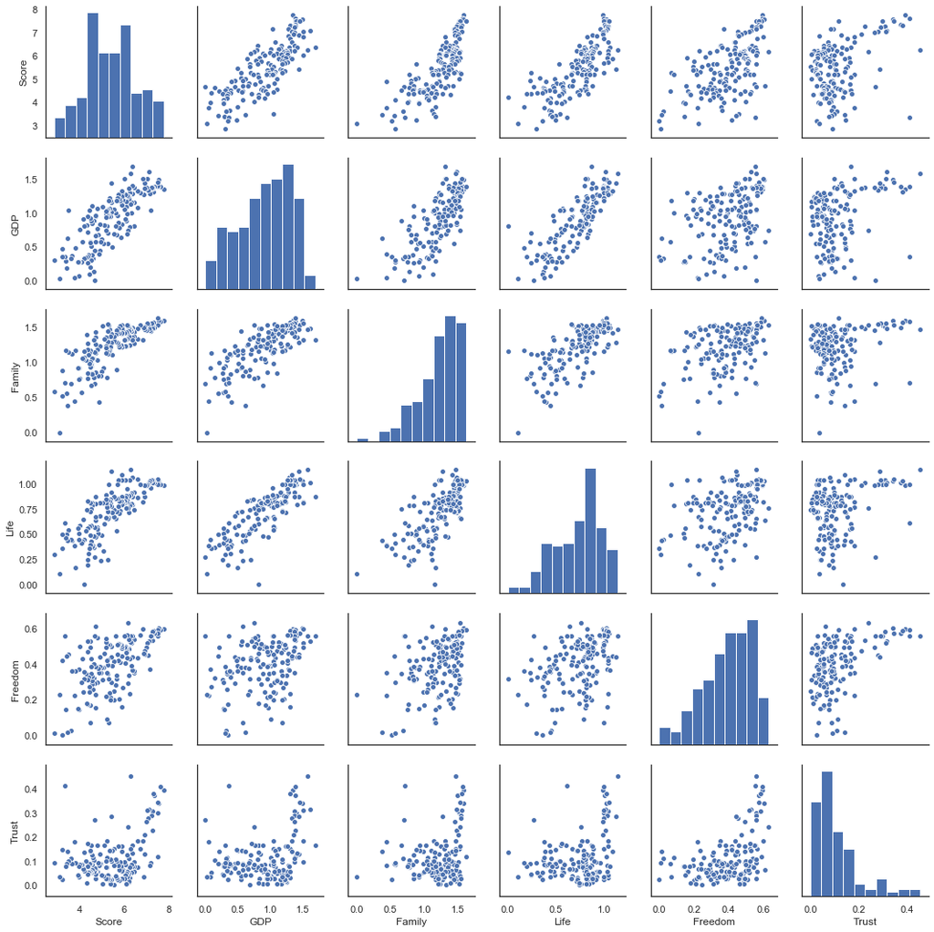

```python
fig = plt.figure(figsize=(20,20))
sns.set(style="white",font_scale=1);
sns.pairplot(df_2019[['Score','GDP', 'Family', 'Life', 'Freedom', 'Trust']]);
```

```python
fig = px.scatter(df_2019, x='Score', y='GDP', text='Country')
fig.update_traces(textposition='top center')
fig.update_layout(
    height=1000,
)
fig.show()
```

[interactive chart not shown]

# Generosity

```python
trace1 = [go.Choropleth(
               colorscale = 'Earth',
               locationmode = 'country names',
               locations = df_2019['Country'],
               text = df_2019['Country'],
               z = df_2019['Generosity'],
               )]

layout = dict(title = 'Generosity',
                  geo = dict(
                      showframe = True,
                      showocean = True,
                      showlakes = True,
                      showcoastlines = True,
                      projection = dict(
                          type = 'hammer'
        )))


projections = [ "equirectangular", "mercator", "orthographic", "natural earth","kavrayskiy7",
               "miller", "robinson", "eckert4", "azimuthal equal area","azimuthal equidistant",
               "conic equal area", "conic conformal", "conic equidistant", "gnomonic", "stereographic",
               "mollweide", "hammer", "transverse mercator", "albers usa", "winkel tripel" ]

buttons = [dict(args = ['geo.projection.type', y],
           label = y, method = 'relayout') for y in projections]
annot = list([ dict( x=0.1, y=0.8, text='Projection', yanchor='bottom',
                    xref='paper', xanchor='right', showarrow=False )])


# Update Layout Object

layout[ 'updatemenus' ] = list([ dict( x=0.1, y=0.8, buttons=buttons, yanchor='top' )])
layout[ 'annotations' ] = annot


fig = go.Figure(data = trace1, layout = layout)
py.iplot(fig)
```

[interactive chart not shown]

- Generosity is really low in Big Countries like Russia and China but USA, Austrelia, and Canada have high ratings for generosity.
- Parts of Africa and South America have very low Generosity Scores in general.

## Ten Most Generous Countries

```python
df_2019[['Country', 'Generosity']].sort_values(by = 'Generosity',
                                                ascending = False).head(10)
```

|  | Country | Generosity |
| --- | --- | --- |
| 130 | Myanmar | 0.566 |
| 91 | Indonesia | 0.498 |
| 146 | Haiti | 0.419 |
| 21 | Malta | 0.375 |
| 120 | Kenya | 0.372 |
| 94 | Bhutan | 0.370 |
| 51 | Thailand | 0.359 |
| 3 | Iceland | 0.354 |
| 14 | United Kingdom | 0.348 |
| 10 | Australia | 0.332 |

# Trust or Perception of Corruption

```python
trace1 = [go.Choropleth(
               colorscale = 'Cividis',
               locationmode = 'country names',
               locations = df_2019['Country'],
               text = df_2019['Country'],
               z = df_2019['Trust'],
               )]

layout = dict(title = 'Trust in Governance',
                  geo = dict(
                      showframe = True,
                      showocean = True,
                      showlakes = True,
                      showcoastlines = True,
                      projection = dict(
                          type = 'hammer'
        )))


projections = [ "equirectangular", "mercator", "orthographic", "natural earth","kavrayskiy7",
               "miller", "robinson", "eckert4", "azimuthal equal area","azimuthal equidistant",
               "conic equal area", "conic conformal", "conic equidistant", "gnomonic", "stereographic",
               "mollweide", "hammer", "transverse mercator", "albers usa", "winkel tripel" ]

buttons = [dict(args = ['geo.projection.type', y],
           label = y, method = 'relayout') for y in projections]
annot = list([ dict( x=0.1, y=0.8, text='Projection', yanchor='bottom',
                    xref='paper', xanchor='right', showarrow=False )])


# Update Layout Object

layout[ 'updatemenus' ] = list([ dict( x=0.1, y=0.8, buttons=buttons, yanchor='top' )])
layout[ 'annotations' ] = annot


fig = go.Figure(data = trace1, layout = layout)
py.iplot(fig)
```

[interactive chart not shown]

- Looks like there is no trust in government all round the world, except Norway, Sweden, Finland etc.

# Top Countries with trust in Government

```python
df_2019[['Country', 'Trust']].sort_values(by = 'Trust',
                                                ascending = False).head(10)
```

|  | Country | Trust |
| --- | --- | --- |
| 33 | Singapore | 0.453 |
| 151 | Rwanda | 0.411 |
| 1 | Denmark | 0.410 |
| 0 | Finland | 0.393 |
| 7 | New Zealand | 0.380 |
| 6 | Sweden | 0.373 |
| 5 | Switzerland | 0.343 |
| 2 | Norway | 0.341 |
| 13 | Luxembourg | 0.316 |
| 15 | Ireland | 0.310 |

# Family or Social Support

```python
trace1 = [go.Choropleth(
               colorscale = 'Portland',
               locationmode = 'country names',
               locations = df_2019['Country'],
               text = df_2019['Country'],
               z = df_2019['Family'],
               )]

layout = dict(title = 'Family Satisfaction Index',
                  geo = dict(
                      showframe = True,
                      showocean = True,
                      showlakes = True,
                      showcoastlines = True,
                      projection = dict(
                          type = 'hammer'
        )))


projections = [ "equirectangular", "mercator", "orthographic", "natural earth","kavrayskiy7",
               "miller", "robinson", "eckert4", "azimuthal equal area","azimuthal equidistant",
               "conic equal area", "conic conformal", "conic equidistant", "gnomonic", "stereographic",
               "mollweide", "hammer", "transverse mercator", "albers usa", "winkel tripel" ]

buttons = [dict(args = ['geo.projection.type', y],
           label = y, method = 'relayout') for y in projections]
annot = list([ dict( x=0.1, y=0.8, text='Projection', yanchor='bottom',
                    xref='paper', xanchor='right', showarrow=False )])


# Update Layout Object

layout[ 'updatemenus' ] = list([ dict( x=0.1, y=0.8, buttons=buttons, yanchor='top' )])
layout[ 'annotations' ] = annot


fig = go.Figure(data = trace1, layout = layout)
py.iplot(fig)
```

[interactive chart not shown]

# Top countries with high Family Satisfaction

```python
df_2019[['Country', 'Family']].sort_values(by = 'Family',
                                                ascending = False).head(10)
```

|  | Country | Family |
| --- | --- | --- |
| 3 | Iceland | 1.624 |
| 0 | Finland | 1.587 |
| 2 | Norway | 1.582 |
| 1 | Denmark | 1.573 |
| 7 | New Zealand | 1.557 |
| 15 | Ireland | 1.553 |
| 10 | Australia | 1.548 |
| 86 | Turkmenistan | 1.538 |
| 14 | United Kingdom | 1.538 |
| 82 | Mongolia | 1.531 |

# Economy

```python
trace1 = [go.Choropleth(
               colorscale = 'Viridis',
               locationmode = 'country names',
               locations = df_2019['Country'],
               text = df_2019['Country'],
               z = df_2019['GDP'],
               )]

layout = dict(title = 'GDP in 2019',
                  geo = dict(
                      showframe = True,
                      showocean = True,
                      showlakes = True,
                      showcoastlines = True,
                      projection = dict(
                          type = 'hammer'
        )))


projections = [ "equirectangular", "mercator", "orthographic", "natural earth","kavrayskiy7",
               "miller", "robinson", "eckert4", "azimuthal equal area","azimuthal equidistant",
               "conic equal area", "conic conformal", "conic equidistant", "gnomonic", "stereographic",
               "mollweide", "hammer", "transverse mercator", "albers usa", "winkel tripel" ]

buttons = [dict(args = ['geo.projection.type', y],
           label = y, method = 'relayout') for y in projections]
annot = list([ dict( x=0.1, y=0.8, text='Projection', yanchor='bottom',
                    xref='paper', xanchor='right', showarrow=False )])


# Update Layout Object

layout[ 'updatemenus' ] = list([ dict( x=0.1, y=0.8, buttons=buttons, yanchor='top' )])
layout[ 'annotations' ] = annot


fig = go.Figure(data = trace1, layout = layout)
py.iplot(fig)
```

[interactive chart not shown]

# Top 10 countries with best Economy

```python
df_2019[['Country', 'GDP']].sort_values(by = 'GDP',
                                                ascending = False).head(10)
```

|  | Country | GDP |
| --- | --- | --- |
| 28 | Qatar | 1.684 |
| 13 | Luxembourg | 1.609 |
| 33 | Singapore | 1.572 |
| 20 | United Arab Emirates | 1.503 |
| 50 | Kuwait | 1.500 |
| 15 | Ireland | 1.499 |
| 2 | Norway | 1.488 |
| 5 | Switzerland | 1.452 |
| 75 | Hong Kong | 1.438 |
| 18 | United States | 1.433 |

# Freedom

```python
trace1 = [go.Choropleth(
               colorscale = 'Picnic',
               locationmode = 'country names',
               locations = df_2019['Country'],
               text = df_2019['Country'],
               z = df_2019['Freedom'],
               )]

layout = dict(title = 'Freedom Index',
                  geo = dict(
                      showframe = True,
                      showocean = True,
                      showlakes = True,
                      showcoastlines = True,
                      projection = dict(
                          type = 'hammer'
        )))


projections = [ "equirectangular", "mercator", "orthographic", "natural earth","kavrayskiy7",
               "miller", "robinson", "eckert4", "azimuthal equal area","azimuthal equidistant",
               "conic equal area", "conic conformal", "conic equidistant", "gnomonic", "stereographic",
               "mollweide", "hammer", "transverse mercator", "albers usa", "winkel tripel" ]

buttons = [dict(args = ['geo.projection.type', y],
           label = y, method = 'relayout') for y in projections]
annot = list([ dict( x=0.1, y=0.8, text='Projection', yanchor='bottom',
                    xref='paper', xanchor='right', showarrow=False )])


# Update Layout Object

layout[ 'updatemenus' ] = list([ dict( x=0.1, y=0.8, buttons=buttons, yanchor='top' )])
layout[ 'annotations' ] = annot


fig = go.Figure(data = trace1, layout = layout)
py.iplot(fig)
```

[interactive chart not shown]

# Top 10 most Freedom oriented countries

```python
df_2019[['Country', 'Freedom']].sort_values(by = 'Freedom', ascending = False).head(10)
```

|  | Country | Freedom |
| --- | --- | --- |
| 40 | Uzbekistan | 0.631 |
| 108 | Cambodia | 0.609 |
| 2 | Norway | 0.603 |
| 20 | United Arab Emirates | 0.598 |
| 0 | Finland | 0.596 |
| 1 | Denmark | 0.592 |
| 3 | Iceland | 0.591 |
| 7 | New Zealand | 0.585 |
| 8 | Canada | 0.584 |
| 6 | Sweden | 0.574 |

# Happiness

```python
trace1 = [go.Choropleth(
               colorscale = 'Electric',
               locationmode = 'country names',
               locations = df_2019['Country'],
               text = df_2019['Country'],
               z = df_2019['Rank'],
               )]

layout = dict(title = 'Happiness Rank',
                  geo = dict(
                      showframe = True,
                      showocean = True,
                      showlakes = True,
                      showcoastlines = True,
                      projection = dict(
                          type = 'hammer'
        )))


projections = [ "equirectangular", "mercator", "orthographic", "natural earth","kavrayskiy7",
               "miller", "robinson", "eckert4", "azimuthal equal area","azimuthal equidistant",
               "conic equal area", "conic conformal", "conic equidistant", "gnomonic", "stereographic",
               "mollweide", "hammer", "transverse mercator", "albers usa", "winkel tripel" ]

buttons = [dict(args = ['geo.projection.type', y],
           label = y, method = 'relayout') for y in projections]

annot = list([ dict( x=0.1, y=0.8, text='Projection', yanchor='bottom',
                    xref='paper', xanchor='right', showarrow=False )])


# Update Layout Object

layout[ 'updatemenus' ] = list([ dict( x=0.1, y=0.8, buttons=buttons, yanchor='top' )])
layout[ 'annotations' ] = annot


fig = go.Figure(data = trace1, layout = layout)
py.iplot(fig)
```

[interactive chart not shown]

## Top 10 Happiest Countries

```python
df_2019[['Country','Rank']].head(10)
```

|  | Country | Rank |
| --- | --- | --- |
| 0 | Finland | 1 |
| 1 | Denmark | 2 |
| 2 | Norway | 3 |
| 3 | Iceland | 4 |
| 4 | Netherlands | 5 |
| 5 | Switzerland | 6 |
| 6 | Sweden | 7 |
| 7 | New Zealand | 8 |
| 8 | Canada | 9 |
| 9 | Austria | 10 |

# Conclusion

#### It seems like the common criticism for "The World Happiness Report" is quite valid. A high focus on GDP and strongly correlated features such as family and life expectancy.

#### It goes well with common wisdom that money makes you happy up to a certain threshold (about 70,000 in the US). Having a good social net is important and family tends to provide that. High life expectancy and health make you worry less about how you'll survive